# IE48B-hw3

Irem Ozturk

12 12 2021

## Introduction

For this homework, datasets “ECG200”,“CBF”,“Ham”,“Plane” and "Trace have been selected from www.timeseriesclassification.com. Aim is to find the best parameter combination in terms of the accuracy rate using different approaches.

```r
library(data.table)
library(ggplot2)
library(repr)
library(rpart)
library(rattle)
library(TSrepr)
library(zoo)
library(TSdist)
library(dtw)
setwd("c:/Users/oztur/Downloads")
current_folder=getwd()
datasets=c('ECG200','CBF','Ham','Plane','Trace')
```

```r
traindata <- list()

trainclass <- list()

for(i in 1:5){
  dataset = datasets[i]
  main_path=sprintf('%s/ClassificationData/%s/%s',current_folder,dataset,dataset)

  dist_path=sprintf('%s/ClassificationData/%s/distances/%s',current_folder,dataset,dataset)

  train_data_path=sprintf('%s_TRAIN.txt',main_path)
  traindata[[i]]=(fread(train_data_path))

  #first column is the class variable
  trainclass[[i]]=t(traindata[[i]][,1]) # takes -1 and 1

  #drop first column
  traindata[[i]]=traindata[[i]][,2:ncol(traindata[[i]])]

}
```

## Representations

To represent the time series Piecewise Aggregate Approximation and SAX representation have been used with parameters paa_segment_length=5, sax_segment_length=4 and the alphebet_size=5. Plots of the selected time series and its representation can be seen below:

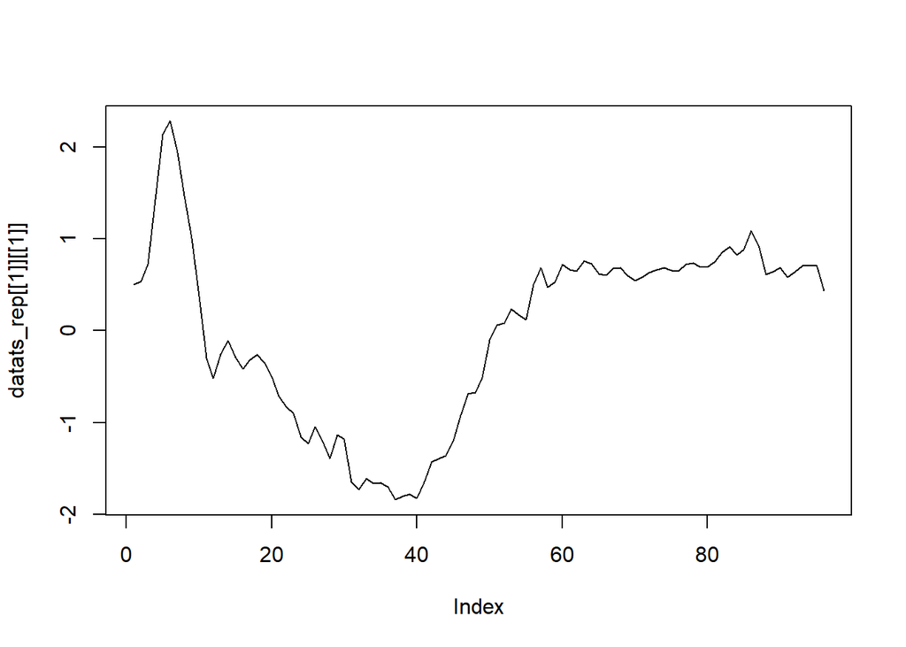

```r
traindata_rep <- list()

trainclass_rep <- list()
longtrain_rep <- list()

for(i in 1:5){
  dataset = datasets[i]
  main_path=sprintf('%s/ClassificationData/%s/%s',current_folder,dataset,dataset)

  dist_path=sprintf('%s/ClassificationData/%s/distances/%s',current_folder,dataset,dataset)

  train_data_path=sprintf('%s_TRAIN.txt',main_path)
  traindata_rep[[i]]=(fread(train_data_path))

  #first column is the class variable
  trainclass_rep[[i]]=t(traindata[[i]][,1]) # takes -1 and 1

setnames(traindata_rep[[i]],'V1','class')
traindata_rep[[i]]=traindata_rep[[i]][order(class)]
traindata_rep[[i]][,class:=as.character(class)]
traindata_rep[[i]][,id:=1:.N]

longtrain_rep[[i]]=melt(traindata_rep[[i]],id.vars=c('id','class'))

longtrain_rep[[i]][,time:=as.numeric(gsub("\\D", "", variable))-1]

longtrain_rep[[i]]=longtrain_rep[[i]][,list(id,class,time,value)]
longtrain_rep[[i]]=longtrain_rep[[i]][order(id,time)]


}

## Piecewise Aggregate Approximation and SAX representation
paarep <- list()
saxrep <- list()
datats_rep <- list()

paarep[[1]] <- list()
paarep[[2]] <- list()
paarep[[3]] <- list()
paarep[[4]] <- list()
paarep[[5]] <- list()

saxrep[[1]] <- list()
saxrep[[2]] <- list()
saxrep[[3]] <- list()
saxrep[[4]] <- list()
saxrep[[5]] <- list()

datats_rep[[1]] <- list()
datats_rep[[2]] <- list()
datats_rep[[3]] <- list()
datats_rep[[4]] <- list()
datats_rep[[5]] <- list()
temp <- c()
for(i in 1:5){
    for(selected_series in 1:nrow(traindata[[i]])){
     segment_length=5

     temp =longtrain_rep[[i]][longtrain_rep[[i]]$id==selected_series]$value
     datats_rep[[i]][[selected_series]] <- temp
      paarep[[i]][[selected_series]]=repr_paa(datats_rep[[i]][[selected_series]], segment_length, meanC)

      sax_segment_length=4
      sax_alphabet_size=5
      saxrep[[i]][[selected_series]]=repr_sax(datats_rep[[i]][[selected_series]], q = sax_segment_length, a = sax_alphabet_size)

    }
}


plot(datats_rep[[1]][[1]], type="l")
```

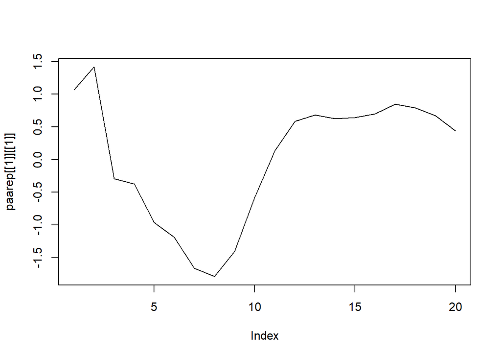

```r
plot(paarep[[1]][[1]], type="l")
```

## Distance Measures

Due to the long run times of the calculations of the distance measures, distance matrices are stored in .csv files.

The only parameter of Nearest Neighbor, namely k is set to 1,3 or 5 throughout the process. In order to evaluate the combinations cross validation with 5 repeats and 10 folds has been used.

```r
nn_classify_cv=function(dist_matrix,train_class,test_indices,k=1){

    test_distances_to_train=dist_matrix[test_indices,]
    test_distances_to_train=test_distances_to_train[,-test_indices]
    train_class=train_class[-test_indices]
    #print(str(test_distances_to_train))
    ordered_indices=apply(test_distances_to_train,1,order)
    if(k==1){
        nearest_class=as.numeric(train_class[as.numeric(ordered_indices[1,])])
        nearest_class=data.table(id=test_indices,nearest_class)
    } else {

        nearest_class=apply(ordered_indices[1:k,],2,function(x) {train_class[x]})
        nearest_class=data.table(id=test_indices,t(nearest_class))
    }

    long_nn_class=melt(nearest_class,'id')

    class_counts=long_nn_class[,.N,list(id,value)]
    class_counts[,predicted_prob:=N/k]
    wide_class_prob_predictions=dcast(class_counts,id~value,value.var='predicted_prob')
    wide_class_prob_predictions[is.na(wide_class_prob_predictions)]=0
    class_predictions=class_counts[,list(predicted=value[which.max(N)]),by=list(id)]


    return(list(prediction=class_predictions,prob_estimates=wide_class_prob_predictions))

}
```

```r
library(TunePareto)

set.seed(13429)
nof_rep=5
n_fold=10

cv_indices_ecg <- list()
cv_indices_cbf <- list()
cv_indices_ham <- list()
cv_indices_plane <- list()
cv_indices_trace <- list()

cv_indices_ecg=generateCVRuns(as.vector(trainclass[[1]]), ntimes =nof_rep, nfold = n_fold,
                         leaveOneOut = FALSE, stratified = TRUE)

cv_indices_cbf=generateCVRuns(as.vector(trainclass[[2]]), ntimes =nof_rep, nfold = n_fold,
                         leaveOneOut = FALSE, stratified = TRUE)

cv_indices_ham=generateCVRuns(as.vector(trainclass[[3]]), ntimes =nof_rep, nfold = n_fold,
                         leaveOneOut = FALSE, stratified = TRUE)


cv_indices_plane=generateCVRuns(as.vector(trainclass[[4]]), ntimes =nof_rep, nfold = n_fold,
                         leaveOneOut = FALSE, stratified = TRUE)


cv_indices_trace=generateCVRuns(as.vector(trainclass[[5]]), ntimes =nof_rep, nfold = n_fold,
                         leaveOneOut = FALSE, stratified = TRUE)
```

```r
dataset='ECG200'
dist_folder=sprintf('%s/ClassificationData/%s/distances/',current_folder,dataset)

dist_files_ecg=as.vector((list.files(dist_folder, full.names=T)))

dataset='CBF'
dist_folder=sprintf('%s/ClassificationData/%s/distances/',current_folder,dataset)

dist_files_cbf=as.vector((list.files(dist_folder, full.names=T)))

dataset='Ham'
dist_folder=sprintf('%s/ClassificationData/%s/distances/',current_folder,dataset)

dist_files_ham=as.vector((list.files(dist_folder, full.names=T)))

dataset='Plane'
dist_folder=sprintf('%s/ClassificationData/%s/distances/',current_folder,dataset)

dist_files_plane=as.vector((list.files(dist_folder, full.names=T)))

dataset='Trace'
dist_folder=sprintf('%s/ClassificationData/%s/distances/',current_folder,dataset)

dist_files_trace=as.vector((list.files(dist_folder, full.names=T)))
```

## ECG200

Overall results for ECG200 data can be seen in table below:

```r
k_levels=c(1,3,5) ##nnk values

dataset='ECG200'

approach_file_ecg <- c("ECG200_dtw_raw_dist",
                        "ECG200_dtw_raw_dist_sakoe_10",
                        "ECG200_dtw_raw_dist_sakoe_20",
                        "ECG200_erp_raw_gap_005",
                        "ECG200_erp_raw_gap_1",
                        "ECG200_euc_raw_dist",
                        "ECG200_lcss_raw_epsilon_005",
                        "ECG200_lcss_raw_epsilon_01")


#approach_file_ecg=dist_files_ecg
result_ecg=vector('list',length(dist_files_ecg)*nof_rep*n_fold*length(k_levels))
iter=1


   for(m in 1:length(dist_files_ecg)) {
     dist_mat=as.matrix(fread(dist_files_ecg[m],header=FALSE))
      for(i in 1:nof_rep){
          this_fold=cv_indices_ecg[[i]]
          for(j in 1:n_fold){
              test_indices=this_fold[[j]]
              for(k in 1:length(k_levels)){
                 current_k=k_levels[k]
                  current_fold=nn_classify_cv(dist_mat,as.vector(trainclass[[1]]),test_indices,k=current_k)
                  accuracy=sum(trainclass[[1]][test_indices]==current_fold$prediction$predicted)/length(test_indices)
                  tmp_ecg=data.table(approach=approach_file_ecg[m],repid=i,foldid=j,dataset=datasets[1],
                               k=current_k,acc=accuracy)
                  result_ecg[[iter]]=tmp_ecg
                  iter=iter+1

             }

         }

      }
   }


overall_results_ecg=rbindlist(result_ecg)
overall_results_ecg[,list(avg_acc=mean(acc),sdev_acc=sd(acc),result_count=.N),by=list(approach,k)]
```

```
##                         approach k avg_acc   sdev_acc result_count
##  1:          ECG200_dtw_raw_dist 1   0.762 0.12270755           50
##  2:          ECG200_dtw_raw_dist 3   0.798 0.09581019           50
##  3:          ECG200_dtw_raw_dist 5   0.762 0.14126253           50
##  4: ECG200_dtw_raw_dist_sakoe_10 1   0.804 0.13241863           50
##  5: ECG200_dtw_raw_dist_sakoe_10 3   0.796 0.13086837           50
##  6: ECG200_dtw_raw_dist_sakoe_10 5   0.780 0.14285714           50
##  7: ECG200_dtw_raw_dist_sakoe_20 1   0.778 0.12337102           50
##  8: ECG200_dtw_raw_dist_sakoe_20 3   0.780 0.09476071           50
##  9: ECG200_dtw_raw_dist_sakoe_20 5   0.766 0.13032142           50
## 10:       ECG200_erp_raw_gap_005 1   0.838 0.09874726           50
## 11:       ECG200_erp_raw_gap_005 3   0.826 0.11747340           50
## 12:       ECG200_erp_raw_gap_005 5   0.774 0.11394592           50
## 13:         ECG200_erp_raw_gap_1 1   0.840 0.09035079           50
## 14:         ECG200_erp_raw_gap_1 3   0.830 0.11293849           50
## 15:         ECG200_erp_raw_gap_1 5   0.814 0.12123514           50
## 16:          ECG200_euc_raw_dist 1   0.868 0.10961901           50
## 17:          ECG200_euc_raw_dist 3   0.910 0.08144110           50
## 18:          ECG200_euc_raw_dist 5   0.868 0.10583005           50
## 19:  ECG200_lcss_raw_epsilon_005 1   0.362 0.12918899           50
## 20:  ECG200_lcss_raw_epsilon_005 3   0.328 0.10309496           50
## 21:  ECG200_lcss_raw_epsilon_005 5   0.334 0.07982123           50
## 22:   ECG200_lcss_raw_epsilon_01 1   0.334 0.10806272           50
## 23:   ECG200_lcss_raw_epsilon_01 3   0.316 0.08889342           50
## 24:   ECG200_lcss_raw_epsilon_01 5   0.306 0.08668498           50
##                         approach k avg_acc   sdev_acc result_count
```

The best combination is Eucledain distance with k=3 in terms of the accuracy mean. In addition the standard deviation of it is relatively small.

## CBF

Overall results for CBF data can be seen in table below:

```r
dataset='CBF'

approach_file_cbf <- c("CBF_dtw_raw_dist",
                        "CBF_dtw_raw_dist_sakoe_10",
                        "CBF_dtw_raw_dist_sakoe_20",
                        "CBF_erp_raw_gap_005",
                        "CBF_erp_raw_gap_1",
                        "CBF_euc_raw_dist",
                        "CBF_lcss_raw_epsilon_005",
                        "CBF_lcss_raw_epsilon_01")

result_cbf=vector('list',length(dist_files_cbf)*nof_rep*n_fold*length(k_levels))
iter=1


   for(m in 1:length(dist_files_cbf)) {
     dist_mat=as.matrix(fread(dist_files_cbf[m],header=FALSE))
      for(i in 1:nof_rep){
          this_fold=cv_indices_cbf[[i]]
          for(j in 1:n_fold){
              test_indices=this_fold[[j]]
              for(k in 1:length(k_levels)){
                 current_k=k_levels[k]
                  current_fold=nn_classify_cv(dist_mat,as.vector(trainclass[[2]]),test_indices,k=current_k)
                  accuracy=sum(trainclass[[2]][test_indices]==current_fold$prediction$predicted)/length(test_indices)
                  tmp_cbf=data.table(approach=approach_file_cbf[m],repid=i,foldid=j,dataset=datasets[2],
                               k=current_k,acc=accuracy)
                  result_cbf[[iter]]=tmp_cbf
                  iter=iter+1

             }

         }

      }
   }


overall_results_cbf=rbindlist(result_cbf)
overall_results_cbf[,list(avg_acc=mean(acc),sdev_acc=sd(acc),result_count=.N),by=list(approach,k)]
```

```
##                      approach k   avg_acc   sdev_acc result_count
##  1:          CBF_dtw_raw_dist 1 1.0000000 0.00000000           50
##  2:          CBF_dtw_raw_dist 3 1.0000000 0.00000000           50
##  3:          CBF_dtw_raw_dist 5 1.0000000 0.00000000           50
##  4: CBF_dtw_raw_dist_sakoe_10 1 0.9600000 0.10942024           50
##  5: CBF_dtw_raw_dist_sakoe_10 3 0.9266667 0.15489006           50
##  6: CBF_dtw_raw_dist_sakoe_10 5 0.9066667 0.15118579           50
##  7: CBF_dtw_raw_dist_sakoe_20 1 1.0000000 0.00000000           50
##  8: CBF_dtw_raw_dist_sakoe_20 3 0.9800000 0.07996598           50
##  9: CBF_dtw_raw_dist_sakoe_20 5 1.0000000 0.00000000           50
## 10:       CBF_erp_raw_gap_005 1 1.0000000 0.00000000           50
## 11:       CBF_erp_raw_gap_005 3 0.9666667 0.10101525           50
## 12:       CBF_erp_raw_gap_005 5 0.9733333 0.09134917           50
## 13:         CBF_erp_raw_gap_1 1 0.9333333 0.13468701           50
## 14:         CBF_erp_raw_gap_1 3 0.9400000 0.12936264           50
## 15:         CBF_erp_raw_gap_1 5 0.9266667 0.13948399           50
## 16:          CBF_euc_raw_dist 1 0.8266667 0.23560604           50
## 17:          CBF_euc_raw_dist 3 0.8600000 0.19154462           50
## 18:          CBF_euc_raw_dist 5 0.8066667 0.22426499           50
## 19:  CBF_lcss_raw_epsilon_005 1 0.2333333 0.15430335           50
## 20:  CBF_lcss_raw_epsilon_005 3 0.1333333 0.16495722           50
## 21:  CBF_lcss_raw_epsilon_005 5 0.1000000 0.15430335           50
## 22:   CBF_lcss_raw_epsilon_01 1 0.1333333 0.16495722           50
## 23:   CBF_lcss_raw_epsilon_01 3 0.1066667 0.15707069           50
## 24:   CBF_lcss_raw_epsilon_01 5 0.1000000 0.15430335           50
##                      approach k   avg_acc   sdev_acc result_count
```

Generally, dynamic time warping works well with this dataset.

## Ham

Overall results for Ham data can be seen in table below:

```r
dataset='Ham'

approach_file_ham <- c("Ham_dtw_raw_dist",
                        "Ham_dtw_raw_dist_sakoe_10",
                        "Ham_dtw_raw_dist_sakoe_20",
                        "Ham_erp_raw_gap_005",
                        "Ham_erp_raw_gap_1",
                        "Ham_euc_raw_dist",
                        "Ham_lcss_raw_epsilon_005",
                        "Ham_lcss_raw_epsilon_01")


result_ham=vector('list',length(dist_files_ham)*nof_rep*n_fold*length(k_levels))
iter=1


   for(m in 1:length(dist_files_ham)) {
     dist_mat=as.matrix(fread(dist_files_ham[m],header=FALSE))
      for(i in 1:nof_rep){
          this_fold=cv_indices_ham[[i]]
          for(j in 1:n_fold){
              test_indices=this_fold[[j]]
              for(k in 1:length(k_levels)){
                 current_k=k_levels[k]
                  current_fold=nn_classify_cv(dist_mat,as.vector(trainclass[[3]]),test_indices,k=current_k)
                  accuracy=sum(trainclass[[3]][test_indices]==current_fold$prediction$predicted)/length(test_indices)
                  tmp_ham=data.table(approach=approach_file_ham[m],repid=i,foldid=j,dataset=datasets[3],
                               k=current_k,acc=accuracy)
                  result_ham[[iter]]=tmp_ham
                  iter=iter+1

             }

         }

      }
   }


overall_results_ham=rbindlist(result_ham)
overall_results_ham[,list(avg_acc=mean(acc),sdev_acc=sd(acc),result_count=.N),by=list(approach,k)]
```

```
##                      approach k   avg_acc   sdev_acc result_count
##  1:          Ham_dtw_raw_dist 1 0.7952727 0.12520504           50
##  2:          Ham_dtw_raw_dist 3 0.8005455 0.10889608           50
##  3:          Ham_dtw_raw_dist 5 0.7952727 0.13679265           50
##  4: Ham_dtw_raw_dist_sakoe_10 1 0.7994545 0.12011983           50
##  5: Ham_dtw_raw_dist_sakoe_10 3 0.8167273 0.11942913           50
##  6: Ham_dtw_raw_dist_sakoe_10 5 0.8054545 0.11326284           50
##  7: Ham_dtw_raw_dist_sakoe_20 1 0.8425455 0.09764368           50
##  8: Ham_dtw_raw_dist_sakoe_20 3 0.8283636 0.10632930           50
##  9: Ham_dtw_raw_dist_sakoe_20 5 0.7987273 0.12728611           50
## 10:       Ham_erp_raw_gap_005 1 0.7909091 0.10915273           50
## 11:       Ham_erp_raw_gap_005 3 0.8056364 0.10317755           50
## 12:       Ham_erp_raw_gap_005 5 0.7598182 0.12840853           50
## 13:         Ham_erp_raw_gap_1 1 0.7981818 0.09844464           50
## 14:         Ham_erp_raw_gap_1 3 0.8336364 0.10310167           50
## 15:         Ham_erp_raw_gap_1 5 0.7694545 0.12870595           50
## 16:          Ham_euc_raw_dist 1 0.8440000 0.09815914           50
## 17:          Ham_euc_raw_dist 3 0.8183636 0.11069461           50
## 18:          Ham_euc_raw_dist 5 0.7820000 0.10857158           50
## 19:  Ham_lcss_raw_epsilon_005 1 0.4612727 0.06944859           50
## 20:  Ham_lcss_raw_epsilon_005 3 0.4329091 0.05990632           50
## 21:  Ham_lcss_raw_epsilon_005 5 0.4401818 0.06977036           50
## 22:   Ham_lcss_raw_epsilon_01 1 0.4740000 0.06033051           50
## 23:   Ham_lcss_raw_epsilon_01 3 0.4478182 0.04717737           50
## 24:   Ham_lcss_raw_epsilon_01 5 0.4423636 0.05745517           50
##                      approach k   avg_acc   sdev_acc result_count
```

The best combinations are Eucledain distance with k=1 and DTW with window size=20 k=1 in terms of the accuracy mean. In addition the standard deviation of them are relatively small.

## Plane

Overall results for Plane data can be seen in table below:

```r
dataset='Plane'

approach_file_plane <- c("Plane_dtw_raw_dist",
                        "Plane_raw_dist_sakoe_10",
                        "Plane_dtw_raw_dist_sakoe_20",
                        "Plane_erp_raw_gap_005",
                        "Plane_erp_raw_gap_1",
                        "Plane_euc_raw_dist",
                        "Plane_lcss_raw_epsilon_005",
                        "Plane_lcss_raw_epsilon_01")

result_plane=vector('list',length(dist_files_plane)*nof_rep*n_fold*length(k_levels))
iter=1


   for(m in 1:length(dist_files_plane)) {
     dist_mat=as.matrix(fread(dist_files_plane[m],header=FALSE))
      for(i in 1:nof_rep){
          this_fold=cv_indices_plane[[i]]
          for(j in 1:n_fold){
              test_indices=this_fold[[j]]
              for(k in 1:length(k_levels)){
                 current_k=k_levels[k]
                  current_fold=nn_classify_cv(dist_mat,as.vector(trainclass[[4]]),test_indices,k=current_k)
                  accuracy=sum(trainclass[[4]][test_indices]==current_fold$prediction$predicted)/length(test_indices)
                  tmp_plane=data.table(approach=approach_file_plane[m],repid=i,foldid=j,dataset=datasets[4],
                               k=current_k,acc=accuracy)
                  result_plane[[iter]]=tmp_plane
                  iter=iter+1

             }

         }

      }
   }


overall_results_plane=rbindlist(result_plane)
overall_results_plane[,list(avg_acc=mean(acc),sdev_acc=sd(acc),result_count=.N),by=list(approach,k)]
```

```
##                        approach k   avg_acc   sdev_acc result_count
##  1:          Plane_dtw_raw_dist 1 1.0000000 0.00000000           50
##  2:          Plane_dtw_raw_dist 3 1.0000000 0.00000000           50
##  3:          Plane_dtw_raw_dist 5 1.0000000 0.00000000           50
##  4:     Plane_raw_dist_sakoe_10 1 1.0000000 0.00000000           50
##  5:     Plane_raw_dist_sakoe_10 3 1.0000000 0.00000000           50
##  6:     Plane_raw_dist_sakoe_10 5 1.0000000 0.00000000           50
##  7: Plane_dtw_raw_dist_sakoe_20 1 1.0000000 0.00000000           50
##  8: Plane_dtw_raw_dist_sakoe_20 3 1.0000000 0.00000000           50
##  9: Plane_dtw_raw_dist_sakoe_20 5 1.0000000 0.00000000           50
## 10:       Plane_erp_raw_gap_005 1 1.0000000 0.00000000           50
## 11:       Plane_erp_raw_gap_005 3 1.0000000 0.00000000           50
## 12:       Plane_erp_raw_gap_005 5 1.0000000 0.00000000           50
## 13:         Plane_erp_raw_gap_1 1 1.0000000 0.00000000           50
## 14:         Plane_erp_raw_gap_1 3 1.0000000 0.00000000           50
## 15:         Plane_erp_raw_gap_1 5 0.9907273 0.02812461           50
## 16:          Plane_euc_raw_dist 1 0.9721818 0.04297151           50
## 17:          Plane_euc_raw_dist 3 0.9850909 0.03912347           50
## 18:          Plane_euc_raw_dist 5 0.9685455 0.06041991           50
## 19:  Plane_lcss_raw_epsilon_005 1 0.0000000 0.00000000           50
## 20:  Plane_lcss_raw_epsilon_005 3 0.0000000 0.00000000           50
## 21:  Plane_lcss_raw_epsilon_005 5 0.0000000 0.00000000           50
## 22:   Plane_lcss_raw_epsilon_01 1 0.0000000 0.00000000           50
## 23:   Plane_lcss_raw_epsilon_01 3 0.0000000 0.00000000           50
## 24:   Plane_lcss_raw_epsilon_01 5 0.0000000 0.00000000           50
##                        approach k   avg_acc   sdev_acc result_count
```

Dynamic time warping and ERP work well.

## Trace

Overall results for Trace data can be seen in table below:

```r
dataset='Trace'

approach_file_trace <- c("Trace_dtw_raw_dist",
                        "Trace_raw_dist_sakoe_10",
                        "Trace_dtw_raw_dist_sakoe_20",
                        "Trace_erp_raw_gap_005",
                        "Trace_erp_raw_gap_1",
                        "Trace_euc_raw_dist",
                        "Trace_lcss_raw_epsilon_005",
                        "Trace_lcss_raw_epsilon_01")

result_trace=vector('list',length(dist_files_trace)*nof_rep*n_fold*length(k_levels))
iter=1


   for(m in 1:length(dist_files_trace)) {
     dist_mat=as.matrix(fread(dist_files_trace[m],header=FALSE))
      for(i in 1:nof_rep){
          this_fold=cv_indices_trace[[i]]
          for(j in 1:n_fold){
              test_indices=this_fold[[j]]
              for(k in 1:length(k_levels)){
                 current_k=k_levels[k]
                  current_fold=nn_classify_cv(dist_mat,as.vector(trainclass[[5]]),test_indices,k=current_k)
                  accuracy=sum(trainclass[[5]][test_indices]==current_fold$prediction$predicted)/length(test_indices)
                  tmp_trace=data.table(approach=approach_file_trace[m],repid=i,foldid=j,dataset=datasets[5],
                               k=current_k,acc=accuracy)
                  result_trace[[iter]]=tmp_trace
                  iter=iter+1

             }

         }

      }
   }


overall_results_trace=rbindlist(result_trace)
overall_results_trace[,list(avg_acc=mean(acc),sdev_acc=sd(acc),result_count=.N),by=list(approach,k)]
```

```
##                        approach k avg_acc   sdev_acc result_count
##  1:          Trace_dtw_raw_dist 1   0.996 0.01979487           50
##  2:          Trace_dtw_raw_dist 3   0.996 0.01979487           50
##  3:          Trace_dtw_raw_dist 5   0.952 0.05436085           50
##  4:     Trace_raw_dist_sakoe_10 1   0.962 0.05303060           50
##  5:     Trace_raw_dist_sakoe_10 3   0.906 0.07398290           50
##  6:     Trace_raw_dist_sakoe_10 5   0.816 0.11313708           50
##  7: Trace_dtw_raw_dist_sakoe_20 1   0.996 0.01979487           50
##  8: Trace_dtw_raw_dist_sakoe_20 3   0.990 0.03030458           50
##  9: Trace_dtw_raw_dist_sakoe_20 5   0.950 0.05439838           50
## 10:       Trace_erp_raw_gap_005 1   0.974 0.04869732           50
## 11:       Trace_erp_raw_gap_005 3   0.896 0.09467452           50
## 12:       Trace_erp_raw_gap_005 5   0.856 0.10133799           50
## 13:         Trace_erp_raw_gap_1 1   0.930 0.06144518           50
## 14:         Trace_erp_raw_gap_1 3   0.854 0.09940640           50
## 15:         Trace_erp_raw_gap_1 5   0.818 0.08964784           50
## 16:          Trace_euc_raw_dist 1   0.830 0.10151907           50
## 17:          Trace_euc_raw_dist 3   0.676 0.11349728           50
## 18:          Trace_euc_raw_dist 5   0.572 0.11612801           50
## 19:  Trace_lcss_raw_epsilon_005 1   0.254 0.07879190           50
## 20:  Trace_lcss_raw_epsilon_005 3   0.310 0.03030458           50
## 21:  Trace_lcss_raw_epsilon_005 5   0.310 0.03030458           50
## 22:   Trace_lcss_raw_epsilon_01 1   0.310 0.03030458           50
## 23:   Trace_lcss_raw_epsilon_01 3   0.304 0.04020356           50
## 24:   Trace_lcss_raw_epsilon_01 5   0.308 0.03404679           50
##                        approach k avg_acc   sdev_acc result_count
```

The Dynamic Time Warping distance measure has created better results.

## BOX-PLOTS

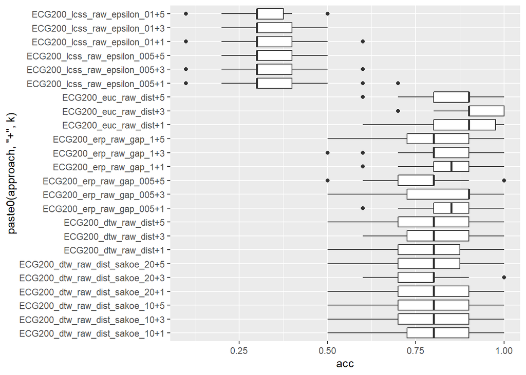

```r
ggplot(overall_results_ecg,aes(x=paste0(approach,'+',k), y=acc)) +geom_boxplot()+ coord_flip()
```

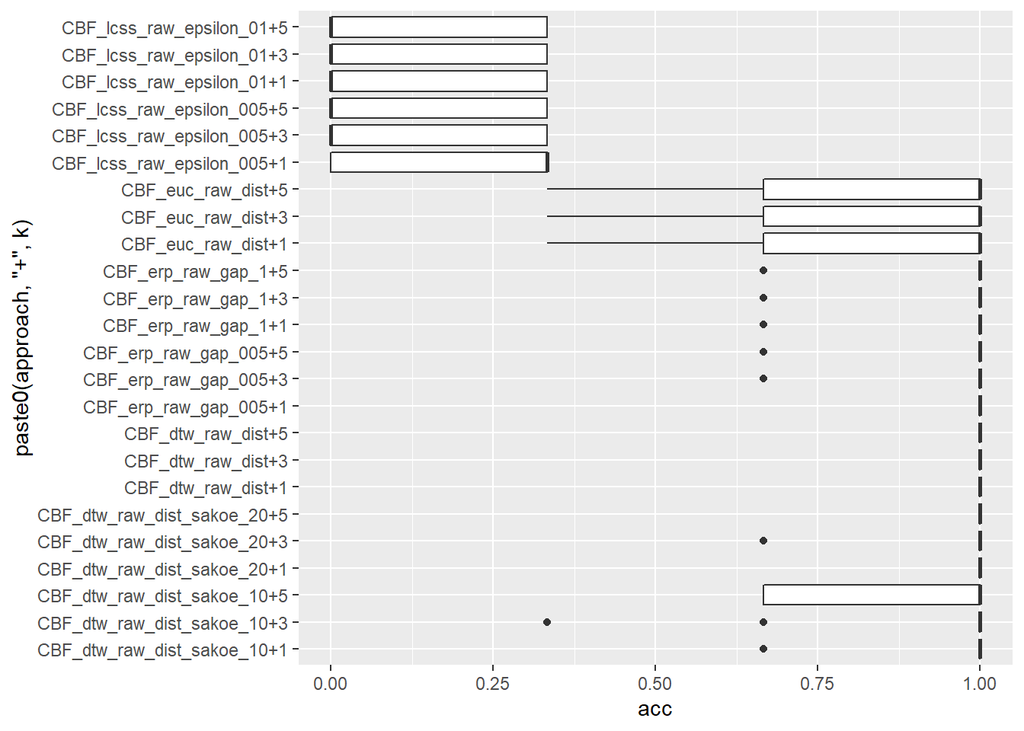

```r
ggplot(overall_results_cbf,aes(x=paste0(approach,'+',k), y=acc)) +geom_boxplot()+ coord_flip()
```

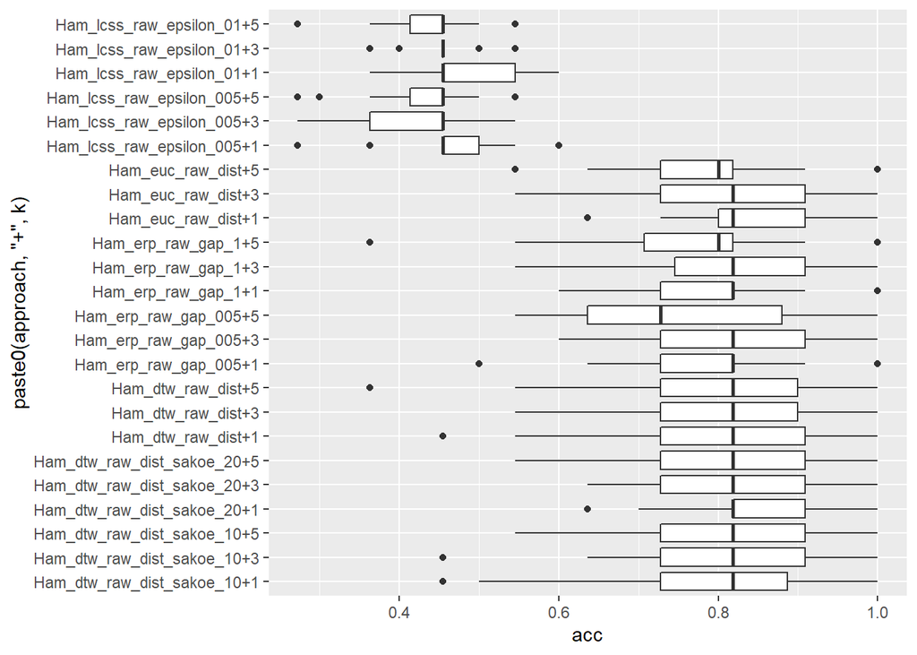

```r
ggplot(overall_results_ham,aes(x=paste0(approach,'+',k), y=acc)) +geom_boxplot()+ coord_flip()
```

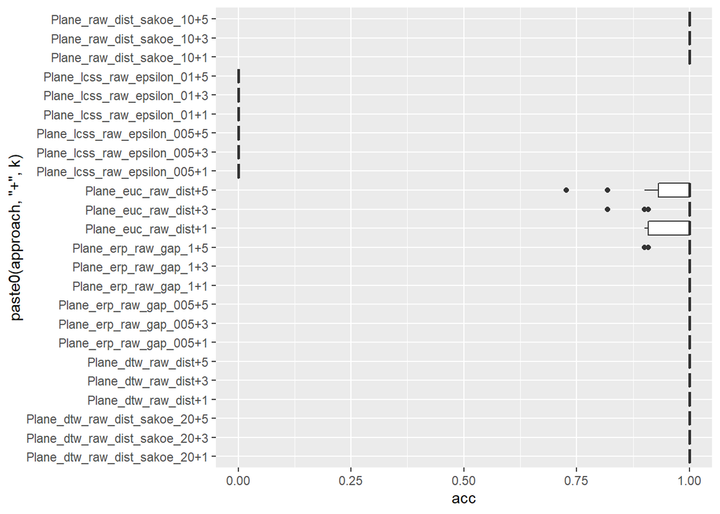

```r
ggplot(overall_results_plane,aes(x=paste0(approach,'+',k), y=acc)) +geom_boxplot()+ coord_flip()
```

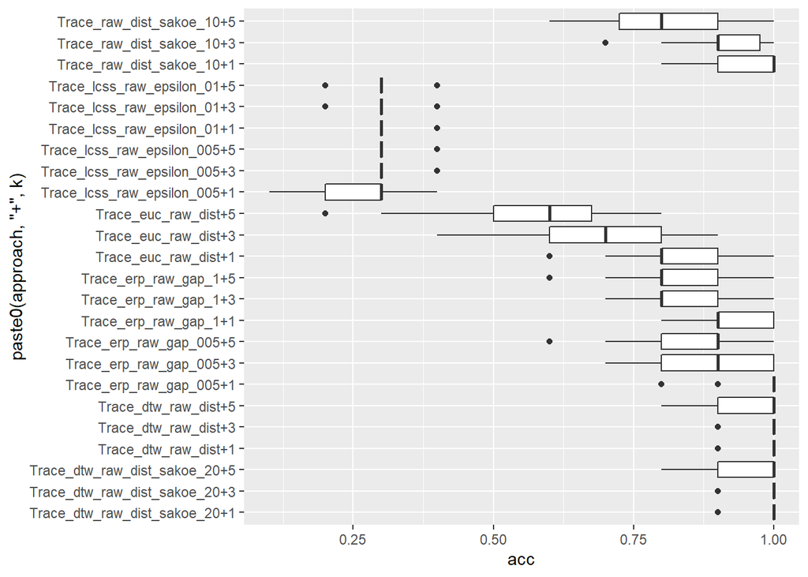

```r
ggplot(overall_results_trace,aes(x=paste0(approach,'+',k), y=acc)) +geom_boxplot()+ coord_flip()
```